# The Election Administration and Voting Survey, 2024

A survey the country’s election offices fill in about themselves, and the empty box that decides who can be compared

Democracy’s Data

Last updated September 13, 2026 at 10:53a EDT

Americans say their elections are run by “the states,” and the sentence is already wrong. Elections are run by 6,461 local offices — county clerks, township boards, city commissions, each receiving the ballots and deciding what to count. So who actually runs American elections, and what does the machinery report about itself? There is exactly one table in which every one of those offices answers the same questions in the same words. It exists because after every federal election, somebody in each office sits down with a questionnaire from Washington and starts filling in boxes.

Two of those boxes carry the stakes. Item C1b asks how many mail ballots came back; item C9a asks how many were rejected. Add C9a up across the country and the answer is 584,463 mail ballots that a voter filled in, sealed, and sent, and that were not counted — about as many people as live in Wyoming.[^1] A ballot that is cast and not counted is a distinct kind of failure. The voter did everything that was asked, the system did not complete the transaction, and in most states nobody is required to tell them.

This brief reads the questionnaire’s answers for 2024. The finding runs in two layers. The machinery varies enormously — the same mailed ballot faces a many-fold difference in rejection risk from state to state. And the survey’s own missing answers are not noise around that finding; in places they *are* the finding, deciding which states can be compared at all.

## The test

The data is the **Election Administration and Voting Survey**, the EAVS: a questionnaire the U.S. Election Assistance Commission sends to every election office in the United States after each federal election, and has since 2004, asking each office how it ran the election — how many voters were registered, how many ballots went out by mail and came back, how many were rejected and why. The Commission publishes every office’s answers as one table, downloadable at https://www.eac.gov/research-and-data/datasets-codebooks-and-surveys. This brief uses the 2024 edition, Version 2, released 12 February 2026 — Version 2 rather than Version 1, because the Commission corrected the first release and published an errata note saying what changed. The survey exists because the Help America Vote Act of 2002, the law Congress passed after the Florida recount, obliged the Commission to report on how federal election law works on the ground.[^2] Congress gave it no power to make any office answer accurately, or at all.

Why this source? Every other election dataset records the *output* of an election. Certified returns — the **canvass**, the official count each state signs off on in the weeks after election day — say who won and are permanently silent about the machinery that took the ballots in; the returns chapter sets out that limit. A rejected mail ballot leaves no trace in the returns, which count what was counted. Only a handful of states publish ballot-level rejection records, which is why the research literature leans so heavily on Florida[^3] and North Carolina.[^4] The EAVS is the one table where all 56 states and territories answer the same question in the same words — the only service record American elections have.

The test is to compute the failure rates the survey supports: mail-ballot rejection nationally, by state, and by stated reason, with **provisional-ballot** rejection beside them — a provisional ballot being the one a voter casts when something is wrong at the polling place, held aside and counted only if the problem checks out. And it is to keep one eye on a second column the whole way — how many offices actually answered each item.

## The data

The public release is one table: 6,461 rows by 535 columns, one row per election office and one column per box on the form. Figure 1 is the form itself, at the two boxes everything below rests on.

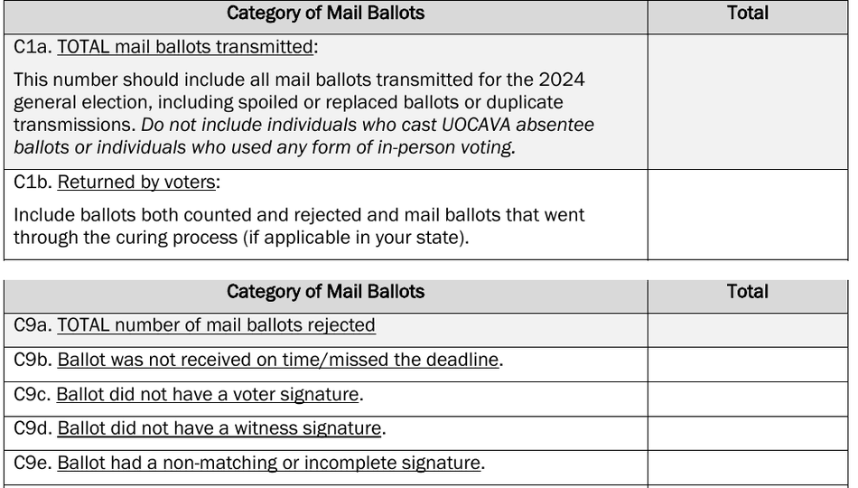

**Figure 1. The instrument.** Items C1a and C1b from page 30 of the 2024 questionnaire, and items C9a to C9e from page 34, as the Commission publishes them. C1b, mail ballots returned, is the denominator of every rejection rate below: the bottom number of the fraction, what you are dividing by. C9a is the numerator, the top number. They are separate boxes, filled in by separate acts of clerical attention, and nothing on the form requires either one.

Here are three rows, sliced to six of the 535 columns:

| FIPSCode | Jurisdiction_Name | … | State_Abbr | … | C1a | C1b | … | C9a | … |
| --- | --- | --- | --- | --- | --- | --- | --- | --- | --- |
| 0100100000 | AUTAUGA COUNTY | … | AL | … | 1822 | -99 | … | 14 | … |
| 0100300000 | BALDWIN COUNTY | … | AL | … | 8902 | -99 | … | 187 | … |
| 1314500000 | HARRIS COUNTY | … | GA | … | 1153 | 1037 | … | 10 | … |

Read the Autauga row as arithmetic and it says the county sent 1,822 mail ballots, got back minus ninety-nine of them, and rejected 14. **The −99 is not a number.** It is the survey’s code for “did not answer,” and −88 means “the question does not apply”; both sit in the same numeric columns as the counts. The file also carries line breaks inside its free-text comment fields, so a program that counts lines says it holds seventeen thousand records where reading it properly finds 6,461.

Four cleaning decisions produce the tables this brief reads. Negative codes become missing, never zero — turned into zero they would silently deflate every total. The numerator and denominator of each rate are counted separately, because the offices answering C1b and C9a are not the same set. Rows are rolled up to states, since the file’s row is an office and the questions worth asking are about states and the country. And nothing is dropped for looking wrong: an office reporting more rejections than returns keeps its row, because no independent record exists to correct it against.

What a row *is* also moves under you:

| State | Jurisdictions | Registered voters | Voters per jurisdiction |
| --- | --- | --- | --- |
| VT | 247 | 361,604 | 1,464 |
| ME | 497 | 842,447 | 1,695 |
| WI | 1851 | 3,434,185 | 1,855 |
| DC | 1 | 328,871 | 328,871 |
| AK | 1 | 340,981 | 340,981 |
| PR | 1 | 1,283,628 | 1,283,628 |

Wisconsin reports 1,851 jurisdictions and Texas 254, because Wisconsin runs elections through townships and Texas through counties. A typical Vermont jurisdiction serves about 1,464 voters and a typical California one about 278,695. So anything averaged over rows, across states, compares things that are not the same kind of thing; totals and rates are safe, and “the average jurisdiction” is not.

The derived tables are four. `national.csv` holds each headline item’s `total`, the count of jurisdictions it was `reported_by`, and `pct_reporting`. `states.csv` holds one row per state: `jurisdictions`, `voters`, `mail_sent`, `mail_returned`, `mail_rejected`, `prov_cast`, `prov_rejected`. `reasons.csv` breaks rejected mail ballots down by the `reason` recorded, with `ballots`, `reported_by`, and `pct_of_rejected`. `units.csv` carries `voters_per_jurisdiction` by state.

> **Before you read on, answer yes or no.** Every rejection rate below is *rejected ÷ returned*: two survey items, with two different response rates. Missing data usually scatters an estimate — some rates too high, some too low, no particular direction. **Does it here?** Write down yes or no, and if no, write down which way it pushes.

## What it says about democracy

| Item | National total | Jurisdictions reporting it | % reporting |
| --- | --- | --- | --- |
| Total voters | 158,211,780 | 6,449 | 99.8 |
| Total precincts | 177,708 | 6,451 | 99.8 |
| Mail ballots transmitted to voters | 66,867,671 | 6,445 | 99.8 |
| Mail ballots returned by voters | 47,957,093 | 6,131 | 94.9 |
| Mail ballots returned undeliverable | 932,533 | 5,843 | 90.4 |
| Mail ballots rejected | 584,463 | 6,361 | 98.5 |
| Provisional ballots cast | 1,736,209 | 5,654 | 87.5 |
| Provisional ballots counted in full | 1,199,465 | 5,621 | 87.0 |
| Provisional ballots rejected | 436,258 | 5,162 | 79.9 |

158,211,780 registered voters, 177,708 precincts, 66,867,671 mail ballots sent out. The two right-hand columns are the ones coverage never quotes: no item is answered by everyone, and provisional-ballot rejections come from 79.9% of offices. **Every national total in this table is a floor**, and the gap between the floor and the truth is unknowable from this file.

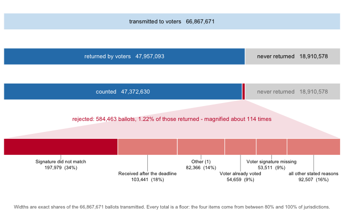

**Figure 2. What happens to a mail ballot, drawn to one scale, with the failure magnified.** Widths are exact shares of the 66,867,671 ballots transmitted, because the point is proportion. The 584,463 rejected ballots are a sliver, 1.22% of the 47,957,093 returned, and the sliver has to be blown up about 114 times before anyone can see inside it. The bottom bar splits it by the reason recorded, largest first: **Signature did not match** alone accounts for 34% of every mail ballot rejected in the country.

The national 1.22% is the number most often quoted, and it hides the actual finding. Do the same arithmetic state by state. Oklahoma’s row says 103,025 mail ballots came back and 4,477 of them were rejected; 4,477 divided by 103,025 is 4.35%. Vermont’s row says 237,565 came back and 467 were rejected, which is 0.20%. Here are the extremes among the 40 states that handled more than 100,000 returned mail ballots:

| State | Mail ballots returned | Rejected | Rate (%) |
| --- | --- | --- | --- |
| OK | 103,025 | 4,477 | 4.35 |
| TX | 398,270 | 14,049 | 3.53 |
| KY | 120,400 | 4,076 | 3.39 |
| MI | 2,081,265 | 63,561 | 3.05 |
| NY | 862,737 | 25,750 | 2.98 |
| VT | 237,565 | 467 | 0.20 |
| IN | 1,607,247 | 3,432 | 0.21 |
| ME | 215,753 | 511 | 0.24 |
| MD | 747,040 | 2,796 | 0.37 |

States handling more than 100,000 returned mail ballots; bars above 2% take the second color. Hover a bar for counts. 4 states and territories are missing from this chart entirely.

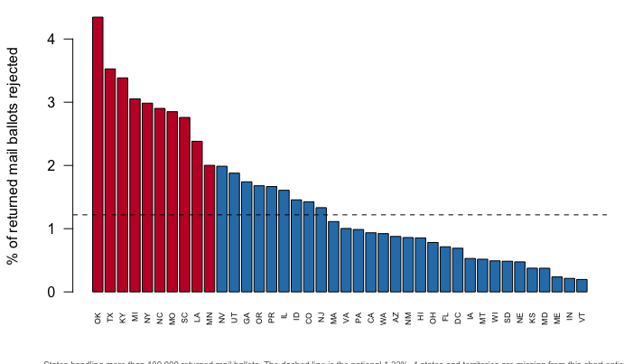

**Figure 3. The chance that a mailed ballot is thrown away, by state.** The 40 states handling more than 100,000 returned mail ballots, ranked by the share rejected; the dashed line is the national 1.22%. Oklahoma sits at 4.35% and Vermont at 0.20%, a 22-fold difference in the same act performed in two states.

That spread is not voters behaving differently in Oklahoma. It is rules — witness requirements, signature matching, postmark deadlines, and above all whether the state lets a voter fix a problem after the fact.[^5] Baringer, Herron and Smith (2020), reading Florida’s ballot-level records, found rejection concentrated among younger voters, voters outside the major parties, and first-time mail voters. A procedural failure that lands harder on particular people is a franchise problem, not a clerical one.

Now the answer to the prompt. **No** — and most readers write yes, because scattering is what missing data usually does. This missing data pushes in one direction, and then it removes whole states from the comparison.

| Item | Jurisdictions | % of the country |
| --- | --- | --- |
| Mail ballots rejected (C9a) — the numerator | 6,361 | 98.5% |
| Mail ballots returned (C1b) — the denominator | 6,131 | 94.9% |
| Jurisdictions reporting a rejection count but no returned count | 230 | 3.6% |

The denominator is measured worse than the numerator: 230 offices told the Commission how many ballots they rejected and not how many came back. Wherever that happens the denominator is short and the rate is too high, in one direction only. At state level it stops being subtle:

| State | Registered voters | Mail ballots sent | Returned | Rejected |
| --- | --- | --- | --- | --- |
| AL | 2,272,911 | 140,558 | 0 | 1,779 |
| CT | 1,820,891 | 129,996 | 0 | 2,642 |
| MP | 12,610 | 1,168 | 0 | 13 |
| MS | 1,225,176 | 28,558 | 0 | 0 |

The reasons column carries the same lesson in a finer grain:

| Reason recorded | Ballots | % of all rejections |
| --- | --- | --- |
| Signature did not match | 197,979 | 33.9 |
| Received after the deadline | 103,441 | 17.7 |
| Other (1) | 82,366 | 14.1 |
| Voter already voted | 54,659 | 9.4 |
| Voter signature missing | 53,511 | 9.2 |
| Missing documentation | 22,175 | 3.8 |

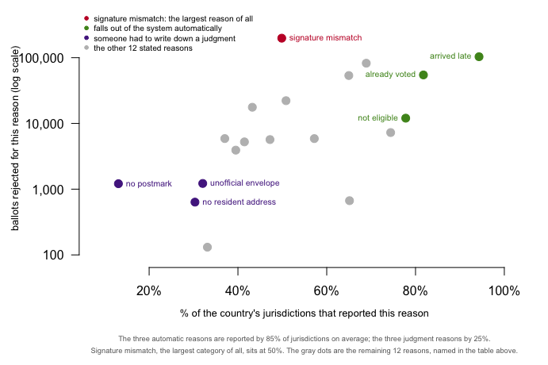

**Figure 4. How many ballots each reason accounts for, against how well it is known.** A scatter, because the finding is the relationship between two columns of `reasons.csv`. Up the page is ballots rejected for that reason, on a log scale, where each step up the axis multiplies the count by ten; across is the share of the country’s 6,461 jurisdictions reporting it. The three reasons an office’s systems record automatically are reported by 85% of jurisdictions on average; the three that need a person to write down a judgment, by 25%. Signature mismatch, the largest category of all at 197,979 ballots, is reported by 50% — we know least about the reason where human discretion matters most.

One more failure is larger and less discussed. A provisional ballot is the safety net for a voter who turns up and something is wrong — not on the list, wrong ID, wrong place.

| Quantity | Value |
| --- | --- |
| Provisional ballots cast | 1,736,209 |
| Counted in full | 1,199,465 |
| Rejected | 436,258 |
| Rejection rate | 25.1% |
| Reported by | 79.9% of jurisdictions |

## What this brief cannot tell you

**It cannot say whether a high-rejection state is strict or careless.** A state that verifies signatures will reject more ballots than one that does not, and that could be integrity working or suppression operating. Both readings produce the same row; telling them apart needs the fifty-one rulebooks, which are not in this file.

**It cannot say who was rejected.** There are no demographics anywhere in the survey. The file counts ballots, not people, which is why the who-gets-rejected findings come from the few states publishing ballot-level records.

**It cannot audit itself.** Every number is a self-report by the office being measured, gathered under a mandate to publish rather than a mandate to comply. The canvass is a different act from the survey: it is a count of votes, certified within weeks under state law, while the survey form is filled in months later from whatever records the office kept, and nothing obliges the two to agree. Where an answer can be set beside the canvass — the residual-votes brief puts the survey’s ballots-cast figure next to the certified presidential vote, county by county — the two disagree in 103 counties. For most items no independent record exists at all.

**And it cannot arrive in time.** The survey covering an election appears more than a year later, so the country receives its election’s service record after the argument about that election is over.

## Extensions

None of these is answered above, and every one can be answered from the tables the Sources section hands over.

- `national.csv` reports `pct_reporting` for every item. Sort by it. Which questions do election offices reliably answer, and what do the skipped ones have in common?
- `units.csv` gives `voters_per_jurisdiction` by state. Compare the extremes. Does “a jurisdiction” mean the same thing in any two states you pick?
- `reasons.csv` has `ballots` and `reported_by` side by side. Compute each reason’s share of 6,461 jurisdictions reporting. Which reasons are about the voter, and which are about the system?
- `states.csv` has `prov_cast` and `prov_rejected`. Compute provisional rejection rates and rank them. Is the spread wider or narrower than for mail?

Two stretch ideas point past the spreadsheet. The Commission publishes the 2022 and 2020 surveys at the same address. Download one and check whether the states at the top of Figure 3 stay at the top, which is what a rules explanation predicts. And look up whether each of your top five states offers a cure process, a chance to fix a rejected envelope, and decide how far that one rule goes toward explaining the ranking.

## Sources

**Data**

- U.S. Election Assistance Commission, *Election Administration and Voting Survey, 2024*, Version 2 — 6,461 jurisdictions, 535 columns, with the official codebook. Version 2 rather than Version 1: V1 was corrected, and the EAC publishes an errata note listing what changed. https://www.eac.gov/research-and-data/datasets-codebooks-and-surveys
- The form in Figure 1 is the EAC’s own **2024 EAVS questionnaire**, cropped to items C1a/C1b and C9a–C9e, retrieved 10 August 2026 and reproduced here so this document needs no network to read. https://www.eac.gov/sites/default/files/2024-04/2024_EAVS_FINAL_508c.pdf

**Academic literature**

- Baringer, A., Herron, M. C. and Smith, D. A. (2020). “Voting by Mail and Ballot Rejection: Lessons from Florida for Elections in the Age of the Coronavirus.” *Election Law Journal* 19(3): 289–320. doi:10.1089/elj.2020.0658
- Merivaki, T. and Smith, D. A. (2020). “A Failsafe for Voters? Cast and Rejected Provisional Ballots in North Carolina.” *Political Research Quarterly* 73(1): 65–78. doi:10.1177/1065912919875816
- Hasen, R. L. (2020). *Election Meltdown: Dirty Tricks, Distrust, and the Threat to American Democracy.* Yale University Press. https://yalebooks.yale.edu/book/9780300248197/election-meltdown/
- Burden, B. C. and Stewart, C. III, eds. (2014). *The Measure of American Elections.* Cambridge University Press.
- Help America Vote Act of 2002, 52 U.S.C. § 20901 and following. https://www.law.cornell.edu/uscode/text/52/20901

**The data itself**

Every figure above is drawn from these tables. They are plain CSV, they open in a spreadsheet, and they are yours to take further.

`national.csv`, `reasons.csv`, `states.csv`, `units.csv`

Rebuild this data yourself, with an AI assistant

```
I want to rebuild a public dataset from its original source, without
any starting files. Please do the following and show your work.

THE SOURCE. U.S. Election Assistance Commission, Election
Administration and Voting Survey, 2024, public release Version 2:
https://www.eac.gov/sites/default/files/2026-02/2024_EAVS_for_Public_Release_nolabel_V2_csv.zip
A zip of about 2 MB expanding to a 41 MB CSV. One row is one local
election jurisdiction -- a county in most states, a township in New
England, Wisconsin and Michigan -- and there are 6,461 of them, with
535 columns each. No account or key is needed. Use Version 2, not
the original release: the first version was corrected, and an errata
note on the same site lists what changed.

Three things in the file itself will silently damage your numbers. Missing answers are coded -99 and
not-applicable items -88, so summing a raw column mixes real counts
with negative codes; drop the negatives before any total. Comment
fields contain line breaks, so counting lines says the file is far
longer than its actual rows; a real CSV parser gets it right. And a
"jurisdiction" is not one kind of thing, so any per-jurisdiction
average compares townships to counties.

WHAT TO BUILD.
1. National totals for the headline items -- registered voters,
   precincts, mail ballots sent, returned, and rejected, provisional
   ballots cast -- each with the number of jurisdictions that
   actually reported it, since no item is reported by everyone.
2. Jurisdictions per state, showing the unit-of-observation problem.

CHECK YOUR WORK. The copy this book used was downloaded in August 2026.
If your rebuild matches it, you should find:
- 6,461 jurisdictions and 535 columns
- 158,211,780 registered voters, reported by 6,449 jurisdictions
- 584,463 mail ballots rejected, and 177,708 precincts
- Wisconsin reports 1,851 jurisdictions; Texas reports 254
The survey runs every two years and this edition has already been
revised once; a further revision would move the numbers because the
EAC corrected them, not because you made an error.
```

[^1]: U.S. Census Bureau, state population totals, 2020–2024: https://www.census.gov/data/tables/time-series/demo/popest/2020s-state-total.html.
[^2]: 52 U.S.C. § 20901 and following: https://www.law.cornell.edu/uscode/text/52/20901.
[^3]: Anna Baringer, Michael C. Herron and Daniel A. Smith, “Voting by Mail and Ballot Rejection: Lessons from Florida for Elections in the Age of the Coronavirus,” *Election Law Journal* 19, no. 3 (2020): 289–320, doi:10.1089/elj.2020.0658.
[^4]: Thessalia Merivaki and Daniel A. Smith, “A Failsafe for Voters? Cast and Rejected Provisional Ballots in North Carolina,” *Political Research Quarterly* 73, no. 1 (2020): 65–78, doi:10.1177/1065912919875816.
[^5]: The National Conference of State Legislatures catalogues these rules state by state: https://www.ncsl.org/elections-and-campaigns/voting-outside-the-polling-place.